# IS362 - FinalProject - Comparing Netflix and Hulu

#### For my final project, I am analyzing genres between two popular streaming services companies; Netflix and Hulu. My motivation for this project came from wondering how movie directors and producers decide what streaming service to stream their movies and/or shows. During quarantine, I often relied on Netflix and Hulu to pass time. When I found myself in the mood to watch certain genres, I knew where to check first.

```python
from IPython.display import Image

Image(url='https://cdn57.androidauthority.net/wp-content/uploads/2019/04/Hulu-vs-netflix.jpg')
```

[figure not shown]

## First, I imported libraries

```python
import pandas as pd
import numpy as np
import matplotlib.pyplot as plt
from matplotlib.pyplot import figure
import seaborn as sns
%matplotlib inline
```

## Read the data. I was lucky to find a csv file that contained both Netflix and Hulu relational data and their genres.

```python
df = pd.read_csv('/Users/jonathan/Documents/MoviesOnStreamingPlatforms_updated.csv', engine='python')
df
```

|  | Unnamed: 0 | ID | Title | Year | Age | IMDb | Rotten Tomatoes | Netflix | Hulu | Prime Video | Disney+ | Type | Directors | Genres | Country | Language | Runtime |
| --- | --- | --- | --- | --- | --- | --- | --- | --- | --- | --- | --- | --- | --- | --- | --- | --- | --- |
| 0 | 0 | 1 | Inception | 2010 | 13+ | 8.8 | 87% | 1 | 0 | 0 | 0 | 0 | Christopher Nolan | Action,Adventure,Sci-Fi,Thriller | United States,United Kingdom | English,Japanese,French | 148.0 |
| 1 | 1 | 2 | The Matrix | 1999 | 18+ | 8.7 | 87% | 1 | 0 | 0 | 0 | 0 | Lana Wachowski,Lilly Wachowski | Action,Sci-Fi | United States | English | 136.0 |
| 2 | 2 | 3 | Avengers: Infinity War | 2018 | 13+ | 8.5 | 84% | 1 | 0 | 0 | 0 | 0 | Anthony Russo,Joe Russo | Action,Adventure,Sci-Fi | United States | English | 149.0 |
| 3 | 3 | 4 | Back to the Future | 1985 | 7+ | 8.5 | 96% | 1 | 0 | 0 | 0 | 0 | Robert Zemeckis | Adventure,Comedy,Sci-Fi | United States | English | 116.0 |
| 4 | 4 | 5 | The Good, the Bad and the Ugly | 1966 | 18+ | 8.8 | 97% | 1 | 0 | 1 | 0 | 0 | Sergio Leone | Western | Italy,Spain,West Germany | Italian | 161.0 |
| ... | ... | ... | ... | ... | ... | ... | ... | ... | ... | ... | ... | ... | ... | ... | ... | ... | ... |
| 16739 | 16739 | 16740 | The Ghosts of Buxley Hall | 1980 | NaN | 6.2 | NaN | 0 | 0 | 0 | 1 | 0 | Bruce Bilson | Comedy,Family,Fantasy,Horror | United States | English | 120.0 |
| 16740 | 16740 | 16741 | The Poof Point | 2001 | 7+ | 4.7 | NaN | 0 | 0 | 0 | 1 | 0 | Neal Israel | Comedy,Family,Sci-Fi | United States | English | 90.0 |
| 16741 | 16741 | 16742 | Sharks of Lost Island | 2013 | NaN | 5.7 | NaN | 0 | 0 | 0 | 1 | 0 | Neil Gelinas | Documentary | United States | English | NaN |
| 16742 | 16742 | 16743 | Man Among Cheetahs | 2017 | NaN | 6.6 | NaN | 0 | 0 | 0 | 1 | 0 | Richard Slater-Jones | Documentary | United States | English | NaN |
| 16743 | 16743 | 16744 | In Beaver Valley | 1950 | NaN | NaN | NaN | 0 | 0 | 0 | 1 | 0 | James Algar | Documentary,Short,Family | United States | English | 32.0 |

16744 rows × 17 columns

```python
df.fillna(value=0, inplace=True)
df
```

|  | Unnamed: 0 | ID | Title | Year | Age | IMDb | Rotten Tomatoes | Netflix | Hulu | Prime Video | Disney+ | Type | Directors | Genres | Country | Language | Runtime |
| --- | --- | --- | --- | --- | --- | --- | --- | --- | --- | --- | --- | --- | --- | --- | --- | --- | --- |
| 0 | 0 | 1 | Inception | 2010 | 13+ | 8.8 | 87% | 1 | 0 | 0 | 0 | 0 | Christopher Nolan | Action,Adventure,Sci-Fi,Thriller | United States,United Kingdom | English,Japanese,French | 148.0 |
| 1 | 1 | 2 | The Matrix | 1999 | 18+ | 8.7 | 87% | 1 | 0 | 0 | 0 | 0 | Lana Wachowski,Lilly Wachowski | Action,Sci-Fi | United States | English | 136.0 |
| 2 | 2 | 3 | Avengers: Infinity War | 2018 | 13+ | 8.5 | 84% | 1 | 0 | 0 | 0 | 0 | Anthony Russo,Joe Russo | Action,Adventure,Sci-Fi | United States | English | 149.0 |
| 3 | 3 | 4 | Back to the Future | 1985 | 7+ | 8.5 | 96% | 1 | 0 | 0 | 0 | 0 | Robert Zemeckis | Adventure,Comedy,Sci-Fi | United States | English | 116.0 |
| 4 | 4 | 5 | The Good, the Bad and the Ugly | 1966 | 18+ | 8.8 | 97% | 1 | 0 | 1 | 0 | 0 | Sergio Leone | Western | Italy,Spain,West Germany | Italian | 161.0 |
| ... | ... | ... | ... | ... | ... | ... | ... | ... | ... | ... | ... | ... | ... | ... | ... | ... | ... |
| 16739 | 16739 | 16740 | The Ghosts of Buxley Hall | 1980 | 0 | 6.2 | 0 | 0 | 0 | 0 | 1 | 0 | Bruce Bilson | Comedy,Family,Fantasy,Horror | United States | English | 120.0 |
| 16740 | 16740 | 16741 | The Poof Point | 2001 | 7+ | 4.7 | 0 | 0 | 0 | 0 | 1 | 0 | Neal Israel | Comedy,Family,Sci-Fi | United States | English | 90.0 |
| 16741 | 16741 | 16742 | Sharks of Lost Island | 2013 | 0 | 5.7 | 0 | 0 | 0 | 0 | 1 | 0 | Neil Gelinas | Documentary | United States | English | 0.0 |
| 16742 | 16742 | 16743 | Man Among Cheetahs | 2017 | 0 | 6.6 | 0 | 0 | 0 | 0 | 1 | 0 | Richard Slater-Jones | Documentary | United States | English | 0.0 |
| 16743 | 16743 | 16744 | In Beaver Valley | 1950 | 0 | 0.0 | 0 | 0 | 0 | 0 | 1 | 0 | James Algar | Documentary,Short,Family | United States | English | 32.0 |

16744 rows × 17 columns

## Deleted the unnecessary columns

```python
df.drop(columns=['Unnamed: 0'], inplace=True)
df.drop(columns=['ID'], inplace=True)
df.drop(columns=['Age'], inplace=True)
df.drop(columns=['IMDb'], inplace=True)
df.drop(columns=['Rotten Tomatoes'], inplace=True)
df.drop(columns=['Prime Video'], inplace=True)
df.drop(columns=['Disney+'], inplace=True)
df.drop(columns=['Type'], inplace=True)
df.drop(columns=['Directors'], inplace=True)
df.drop(columns=['Runtime'], inplace=True)
```

```python
df
```

|  | Title | Year | Netflix | Hulu | Genres | Country | Language |
| --- | --- | --- | --- | --- | --- | --- | --- |
| 0 | Inception | 2010 | 1 | 0 | Action,Adventure,Sci-Fi,Thriller | United States,United Kingdom | English,Japanese,French |
| 1 | The Matrix | 1999 | 1 | 0 | Action,Sci-Fi | United States | English |
| 2 | Avengers: Infinity War | 2018 | 1 | 0 | Action,Adventure,Sci-Fi | United States | English |
| 3 | Back to the Future | 1985 | 1 | 0 | Adventure,Comedy,Sci-Fi | United States | English |
| 4 | The Good, the Bad and the Ugly | 1966 | 1 | 0 | Western | Italy,Spain,West Germany | Italian |
| ... | ... | ... | ... | ... | ... | ... | ... |
| 16739 | The Ghosts of Buxley Hall | 1980 | 0 | 0 | Comedy,Family,Fantasy,Horror | United States | English |
| 16740 | The Poof Point | 2001 | 0 | 0 | Comedy,Family,Sci-Fi | United States | English |
| 16741 | Sharks of Lost Island | 2013 | 0 | 0 | Documentary | United States | English |
| 16742 | Man Among Cheetahs | 2017 | 0 | 0 | Documentary | United States | English |
| 16743 | In Beaver Valley | 1950 | 0 | 0 | Documentary,Short,Family | United States | English |

16744 rows × 7 columns

## Started with Hulu's relational data.

```python
df_hulu = df[df['Hulu'] == 1]
```

```python
from collections import Counter

def return_counter(data_frame, column_name, limit):
    print(dict(Counter(data_frame[column_name].values).most_common(limit)))
```

```python
return_counter(df_hulu, 'Language', 20)
```

```
{'English': 607, 'English,Spanish': 27, 'Japanese': 19, 'English,French': 18, 0: 15, 'Spanish': 8, 'English,Mandarin': 7, 'French': 6, 'English,Italian': 5, 'Korean': 5, 'English,Korean': 4, 'English,Klingon': 4, 'Spanish,English': 4, 'English,French,German': 4, 'French,English': 4, 'English,Russian…
```

```python
df_hulu['Language'].value_counts()
```

```
English                                                     607
English,Spanish                                              27
Japanese                                                     19
English,French                                               18
0                                                            15
                                                           ...
English,Spanish,Norwegian,French,Korean,Greek,Vietnamese      1
English,Croatian,Chinese                                      1
English,Punjabi,Hindi,German                                  1
English,Armenian                                              1
Persian                                                       1
Name: Language, Length: 151, dtype: int64
```

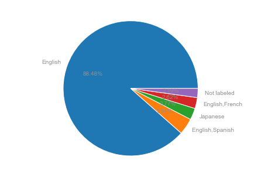

```python
fig = plt.figure()
ax = fig.add_axes([0,0,1,1])
ax.axis('equal')
languages = ['English', 'English,Spanish ', 'Japanese', 'English,French', 'Not labeled']
titles = [607, 27, 19, 18, 15]
ax.pie(titles, labels = languages,autopct='%1.2f%%')
plt.show()
```

```python
return_counter(df_hulu, 'Genres', 20)
```

```
{'Documentary': 75, 'Drama': 44, 'Comedy,Drama': 38, 'Comedy': 36, 'Drama,Romance': 30, 'Comedy,Drama,Romance': 30, 'Horror,Thriller': 21, 'Comedy,Romance': 20, 'Drama,Thriller': 15, 'Horror': 13, 'Drama,Horror,Thriller': 11, 'Crime,Drama,Thriller': 11, 'Family': 10, 'Animation,Adventure,Comedy,Fami…
```

```python
df_hulu['Genres'].value_counts()
```

```
Documentary                                        75
Drama                                              44
Comedy,Drama                                       38
Comedy                                             36
Drama,Romance                                      30
                                                   ..
Animation,Drama,Sci-Fi,Thriller                     1
Animation,Action,Adventure,Fantasy,Sci-Fi           1
Mystery                                             1
Documentary,Comedy,Drama,Family,Fantasy,Romance     1
Action,Drama,Thriller,War                           1
Name: Genres, Length: 327, dtype: int64
```

#### Based on this data, documentaries are most likely to be streamed on Hulu.

[figure not shown]

```python
fig = plt.figure()
ax = fig.add_axes([0,0,1,1])
Genres = ['Documentary', 'Drama', 'Comedy,Drama', 'Comedy', 'Drama,Romance']
Hulu_titles = [75,44,38,36,30]
ax.bar(Genres, Hulu)
plt.show()
```

## Then Netflix's data.

```python
df_netflix = df[df['Netflix'] == 1]
```

```python
return_counter(df_netflix, 'Language', 20)
```

```
{'English': 1624, 'Hindi': 252, 0: 178, 'Spanish': 148, 'English,Spanish': 67, 'French': 48, 'Japanese': 47, 'Arabic': 46, 'Hindi,English': 45, 'English,French': 45, 'Turkish': 44, 'Punjabi': 37, 'Malayalam': 36, 'Tamil': 31, 'Indonesian': 30, 'Thai': 27, 'Marathi': 24, 'Filipino,Tagalog': 22, 'Cant…
```

```python
df_netflix['Language'].value_counts()
```

```
English                                                       1624
Hindi                                                          252
0                                                              178
Spanish                                                        148
English,Spanish                                                 67
                                                              ...
English,Turkmen,Cantonese,Italian,Spanish,Ukrainian,French       1
Filipino,Tagalog,Japanese,Korean                                 1
English,Cheyenne,French                                          1
English,Russian,Hungarian,French,Turkish                         1
English,Khmer                                                    1
Name: Language, Length: 431, dtype: int64
```

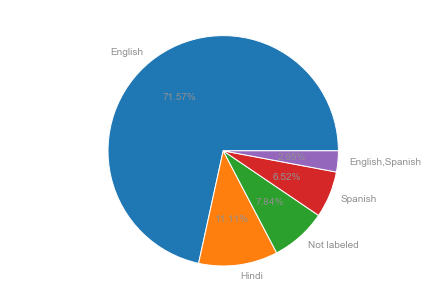

```python
fig = plt.figure()
ax = fig.add_axes([0,0,1,1])
ax.axis('equal')
languages = ['English', 'Hindi', 'Not labeled', 'Spanish', 'English,Spanish']
titles = [1624,252,178,148,67]
ax.pie(titles, labels = languages,autopct='%1.2f%%')
plt.show()
```

```python
return_counter(df_netflix, 'Genres', 20)
```

```
{'Comedy': 424, 'Drama': 259, 'Documentary': 241, 'Comedy,Drama': 129, 'Comedy,Drama,Romance': 100, 'Drama,Romance': 92, 0: 91, 'Comedy,Romance': 88, 'Documentary,Comedy': 57, 'Thriller': 46, 'Horror,Thriller': 43, 'Crime,Drama,Thriller': 40, 'Action,Thriller': 39, 'Drama,Thriller': 35, 'Horror': 30…
```

```python
df_netflix['Genres'].value_counts()
```

```
Comedy                                           424
Drama                                            259
Documentary                                      241
Comedy,Drama                                     129
Comedy,Drama,Romance                             100
                                                ...
Drama,Fantasy,Thriller                             1
Documentary,Biography,History,Music                1
Action,Drama,History                               1
Comedy,Drama,Romance,Sci-Fi,Thriller               1
Action,Adventure,Comedy,Family,Fantasy,Sci-Fi      1
Name: Genres, Length: 683, dtype: int64
```

#### Based on this data, comedy movies and/or tv shows are most likely to stream on Netflix.

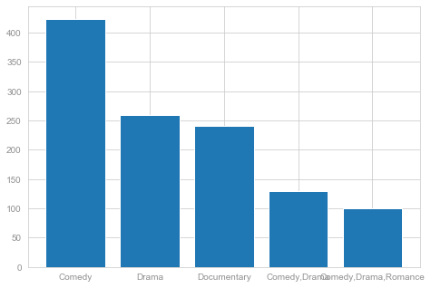

```python
fig = plt.figure()
ax = fig.add_axes([0,0,1,1])
Genres = ['Comedy', 'Drama', 'Documentary', 'Comedy,Drama', 'Comedy,Drama,Romance']
Netflix = [424,259,241,129,100]
ax.bar(Genres, Netflix)
plt.show()
```

```python
df.dtypes
```

```
Title       object
Year         int64
Netflix      int64
Hulu         int64
Genres      object
Country     object
Language    object
dtype: object
```

```python
df[['Genres']] = df[['Genres']].apply(pd.to_numeric, errors ='coerce')
df[['Language']] = df[['Language']].apply(pd.to_numeric, errors ='coerce')

df.dtypes
```

```
Title        object
Year          int64
Netflix       int64
Hulu          int64
Genres      float64
Country      object
Language    float64
dtype: object
```

```python
df_hulu = df_hulu.groupby('Genres')['Hulu'].sum()
df_hulu
```

```
Genres
0                                               6
Action                                          3
Action,Adventure                                2
Action,Adventure,Comedy                         3
Action,Adventure,Comedy,Crime,Drama,Thriller    1
                                               ..
Short,Family                                    1
Short,Western                                   1
Talk-Show                                       1
Thriller                                        5
Western                                         2
Name: Hulu, Length: 327, dtype: int64
```

```python
df_netflix = df_netflix.groupby('Genres')['Netflix'].sum()
df_netflix
```

```
Genres
0                                           91
Action                                      19
Action,Adventure                             7
Action,Adventure,Biography,Drama,History     1
Action,Adventure,Comedy                      8
                                            ..
Short,War                                    1
Sport                                        3
Talk-Show                                    3
Thriller                                    46
Western                                      4
Name: Netflix, Length: 683, dtype: int64
```

```python
return_counter(df, 'Genres', 20)
```

```
{0.0: 275, nan: 1, nan: 1, nan: 1, nan: 1, nan: 1, nan: 1, nan: 1, nan: 1, nan: 1, nan: 1, nan: 1, nan: 1, nan: 1, nan: 1, nan: 1, nan: 1, nan: 1, nan: 1, nan: 1}
```

```python
df['Genres'].value_counts()
```

```
0.0    275
Name: Genres, dtype: int64
```

[figure not shown]

```python
N = 5
df_hulu = (75, 44, 38, 36, 30)
df_netflix = (424, 259, 241, 129, 100)
Genres = (2, 3, 4, 1, 2)
Language = (3, 5, 2, 3, 3)
ind = np.arange(N)    # the x locations for the groups
width = 0.5       # the width of the bars: can also be len(x) sequence

p1 = plt.bar(ind, Netflix, width, yerr=Netflix)
p2 = plt.bar(ind, Hulu, width,
             bottom=Netflix, yerr=Hulu)

plt.ylabel('Titles')
plt.title('Titles by Genres')
plt.xticks(ind, ('Drama', 'Documentary ', 'Comedy', 'Comedy,Drama', 'Horror'))
plt.yticks(np.arange(0, 81, 10))
plt.legend((p1[0], p2[0]), ('Netflix', 'Hulu'))

plt.show()
```

##### While doing this project, I encounted a few challenges. For starters, this data is constantly being updated because new movies/shows are being added or removed. Especially on Hulu. Another challenge was that these movies/shows are labeled under more than one genre. For this reason, I included the languages that Netflix and Hulu provides their movies/shows in. English are the popular languages on both (no surprise!), while Hindi comes in second on Netflix followed by Spanish. Hulu on the other hand, only has a few Spanish movies/shows followed by Japanese movies/shows.

#### I created my presentation slides directly from my Jupyter Notebook.